# Warm Up Python

Para un proyecto de ML es importante realizar una análisis previo de los datos con el fin de alistarlos para la fase de modelamiento.

## Objetivo:

El objetivo de este taller es aprender códigos básicos que te permitiran abordar en tus proyectos personales la fase de preprocesamiento y exploración de los datos.

## Manipulación de Datos con Pandas

Pandas es un paquete creado sobre Numpy, los `DataFrame` son conjunto de datos multidimensionales con etiquetas de fila y columna. Ademas de ofrecer una interfaz de almacenamiento para datos etiquetados, Pandas implementa potentes operaciones de datos.

### Instalando Pandas

La instalación de Pandas requiere en el sistema el paquete Numpy.

Para instalarlo se usa el comando:

```
# Instalacion con pip
pip install pandas

# Instalacion con conda
conda install pandas
```

```python
# Si no se tiene pandas instalado
!pip install pandas
```

Luego de instalado, se importa y se puede chequear la version de la siguiente manera:

```python
# Importando librerias
import pandas as pd
import numpy as np
```

```python
# Version de Pandas
pd.__version__
```

```
'1.0.5'
```

### Objetos de Pandas

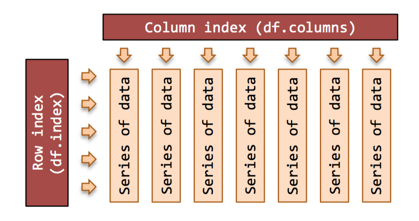

```python
from IPython.display import Image
Image(filename='base_01_pandas_5_0.png', width=500)
# Resource: https://bookdata.readthedocs.io/en/latest/base/01_pandas.html
```

[figure not shown]

### Titanic Dataset

Trabajemos con el famoso conjunto de datos del [titanic](https://www.kaggle.com/c/titanic/data).

- PassengerId -- A numerical id assigned to each passenger.
- Survived -- Whether the passenger survived (1), or didn't (0).
- Pclass -- The class the passenger was in.
- Name -- the name of the passenger.
- Sex -- The gender of the passenger -- male or female.
- Age -- The age of the passenger. Fractional.
- SibSp -- The number of siblings and spouses the passenger had on board.
- Parch -- The number of parents and children the passenger had on board.
- Ticket -- The ticket number of the passenger.
- Fare -- How much the passenger paid for the ticket.
- Cabin -- Which cabin the passenger was in.
- Embarked -- Where the passenger boarded the Titanic.

```python
# Cargamos el archivo
titanic = pd.read_csv("Datasets/train.csv")
```

```python
titanic.index
```

```
RangeIndex(start=0, stop=891, step=1)
```

```python
titanic.columns
```

```
Index(['PassengerId', 'Survived', 'Pclass', 'Name', 'Sex', 'Age', 'SibSp',
       'Parch', 'Ticket', 'Fare', 'Cabin', 'Embarked'],
      dtype='object')
```

```python
type(titanic.PassengerId)
```

```
pandas.core.series.Series
```

```python
type(titanic)
```

```
pandas.core.frame.DataFrame
```

```python
titanic.values
```

```
array([[1, 0, 3, ..., 7.25, nan, 'S'],
       [2, 1, 1, ..., 71.2833, 'C85', 'C'],
       [3, 1, 3, ..., 7.925, nan, 'S'],
       ...,
       [889, 0, 3, ..., 23.45, nan, 'S'],
       [890, 1, 1, ..., 30.0, 'C148', 'C'],
       [891, 0, 3, ..., 7.75, nan, 'Q']], dtype=object)
```

### Indexers: loc, and iloc

Pandas proporciona algunos atributos especiales *indexer* que exponen explícitamente ciertos esquemas de indexación.

Estos no son métodos funcionales, sino atributos que exponen una interfaz de corte particular a los datos.

Primero, el atributo `loc` permite indexar y segmentar que siempre hace referencia al índice explícito.

El atributo `iloc` permite indexar y segmentar que siempre hace referencia al índice implícito de estilo Python.

```python
titanic.loc[10:15,'PassengerId':'Age']
```

|  | PassengerId | Survived | Pclass | Name | Sex | Age |
| --- | --- | --- | --- | --- | --- | --- |
| 10 | 11 | 1 | 3 | Sandstrom, Miss. Marguerite Rut | female | 4.0 |
| 11 | 12 | 1 | 1 | Bonnell, Miss. Elizabeth | female | 58.0 |
| 12 | 13 | 0 | 3 | Saundercock, Mr. William Henry | male | 20.0 |
| 13 | 14 | 0 | 3 | Andersson, Mr. Anders Johan | male | 39.0 |
| 14 | 15 | 0 | 3 | Vestrom, Miss. Hulda Amanda Adolfina | female | 14.0 |
| 15 | 16 | 1 | 2 | Hewlett, Mrs. (Mary D Kingcome) | female | 55.0 |

```python
titanic.iloc[10:15,0:5]
```

|  | PassengerId | Survived | Pclass | Name | Sex |
| --- | --- | --- | --- | --- | --- |
| 10 | 11 | 1 | 3 | Sandstrom, Miss. Marguerite Rut | female |
| 11 | 12 | 1 | 1 | Bonnell, Miss. Elizabeth | female |
| 12 | 13 | 0 | 3 | Saundercock, Mr. William Henry | male |
| 13 | 14 | 0 | 3 | Andersson, Mr. Anders Johan | male |
| 14 | 15 | 0 | 3 | Vestrom, Miss. Hulda Amanda Adolfina | female |

### Selección de datos

```python
# slicing by implicit index
titanic[10:15]
```

|  | PassengerId | Survived | Pclass | Name | Sex | Age | SibSp | Parch | Ticket | Fare | Cabin | Embarked |
| --- | --- | --- | --- | --- | --- | --- | --- | --- | --- | --- | --- | --- |
| 10 | 11 | 1 | 3 | Sandstrom, Miss. Marguerite Rut | female | 4.0 | 1 | 1 | PP 9549 | 16.7000 | G6 | S |
| 11 | 12 | 1 | 1 | Bonnell, Miss. Elizabeth | female | 58.0 | 0 | 0 | 113783 | 26.5500 | C103 | S |
| 12 | 13 | 0 | 3 | Saundercock, Mr. William Henry | male | 20.0 | 0 | 0 | A/5. 2151 | 8.0500 | NaN | S |
| 13 | 14 | 0 | 3 | Andersson, Mr. Anders Johan | male | 39.0 | 1 | 5 | 347082 | 31.2750 | NaN | S |
| 14 | 15 | 0 | 3 | Vestrom, Miss. Hulda Amanda Adolfina | female | 14.0 | 0 | 0 | 350406 | 7.8542 | NaN | S |

```python
# fancy indexing
titanic[['PassengerId','Age']][10:15]
```

|  | PassengerId | Age |
| --- | --- | --- |
| 10 | 11 | 4.0 |
| 11 | 12 | 58.0 |
| 12 | 13 | 20.0 |
| 13 | 14 | 39.0 |
| 14 | 15 | 14.0 |

```python
# masking
titanic[(titanic.Age > 18) & (titanic['Age'] < 50)][10:15]
```

|  | PassengerId | Survived | Pclass | Name | Sex | Age | SibSp | Parch | Ticket | Fare | Cabin | Embarked |
| --- | --- | --- | --- | --- | --- | --- | --- | --- | --- | --- | --- | --- |
| 21 | 22 | 1 | 2 | Beesley, Mr. Lawrence | male | 34.0 | 0 | 0 | 248698 | 13.0000 | D56 | S |
| 23 | 24 | 1 | 1 | Sloper, Mr. William Thompson | male | 28.0 | 0 | 0 | 113788 | 35.5000 | A6 | S |
| 25 | 26 | 1 | 3 | Asplund, Mrs. Carl Oscar (Selma Augusta Emilia... | female | 38.0 | 1 | 5 | 347077 | 31.3875 | NaN | S |
| 27 | 28 | 0 | 1 | Fortune, Mr. Charles Alexander | male | 19.0 | 3 | 2 | 19950 | 263.0000 | C23 C25 C27 | S |
| 30 | 31 | 0 | 1 | Uruchurtu, Don. Manuel E | male | 40.0 | 0 | 0 | PC 17601 | 27.7208 | NaN | C |

```python
titanic['Age'][10:15]
```

```
10     4.0
11    58.0
12    20.0
13    39.0
14    14.0
Name: Age, dtype: float64
```

### Anatomia de un Dataframe

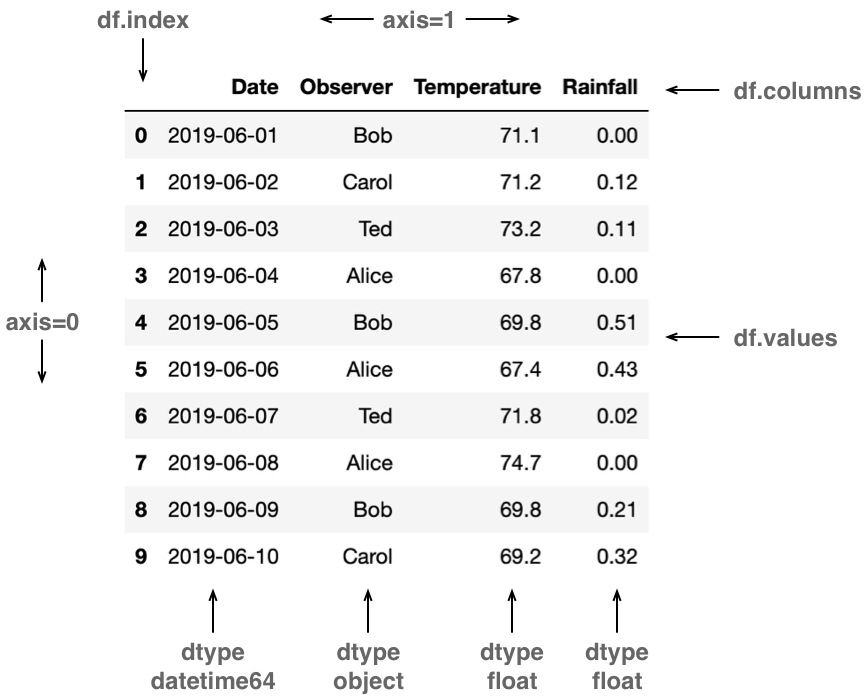

```python
from IPython.display import Image
Image(filename='AnatomyDataFrame.png', width=500)
#Resource: https://cvw.cac.cornell.edu/PyDataSci1/arrays_dataframes
```

[figure not shown]

### concat

Pandas tiene una función, `pd.concat()`, que tiene una sintaxis similar a `np.concatenate` pero contiene una diferentes argumentos.

`pd.concat()` puede ser usado para una concatenacion simple de `Series` o `DataFrames`:

```python
df1 = titanic[(titanic.Age > 18) & (titanic['Age'] < 50)][10:15][['PassengerId','Survived']]
df1.reset_index(inplace = True)
#df1
```

```python
df2 = titanic.iloc[10:15,2:5]
df2.reset_index(inplace = True)
#df2
```

```python
pd.concat([df1, df2],sort=True, axis=1)
```

|  | index | PassengerId | Survived | index | Pclass | Name | Sex |
| --- | --- | --- | --- | --- | --- | --- | --- |
| 0 | 21 | 22 | 1 | 10 | 3 | Sandstrom, Miss. Marguerite Rut | female |
| 1 | 23 | 24 | 1 | 11 | 1 | Bonnell, Miss. Elizabeth | female |
| 2 | 25 | 26 | 1 | 12 | 3 | Saundercock, Mr. William Henry | male |
| 3 | 27 | 28 | 0 | 13 | 3 | Andersson, Mr. Anders Johan | male |
| 4 | 30 | 31 | 0 | 14 | 3 | Vestrom, Miss. Hulda Amanda Adolfina | female |

```python
pd.concat([df1, df2],ignore_index=True,sort=True, axis=0)
```

|  | Name | PassengerId | Pclass | Sex | Survived | index |
| --- | --- | --- | --- | --- | --- | --- |
| 0 | NaN | 22.0 | NaN | NaN | 1.0 | 21 |
| 1 | NaN | 24.0 | NaN | NaN | 1.0 | 23 |
| 2 | NaN | 26.0 | NaN | NaN | 1.0 | 25 |
| 3 | NaN | 28.0 | NaN | NaN | 0.0 | 27 |
| 4 | NaN | 31.0 | NaN | NaN | 0.0 | 30 |
| 5 | Sandstrom, Miss. Marguerite Rut | NaN | 3.0 | female | NaN | 10 |
| 6 | Bonnell, Miss. Elizabeth | NaN | 1.0 | female | NaN | 11 |
| 7 | Saundercock, Mr. William Henry | NaN | 3.0 | male | NaN | 12 |
| 8 | Andersson, Mr. Anders Johan | NaN | 3.0 | male | NaN | 13 |
| 9 | Vestrom, Miss. Hulda Amanda Adolfina | NaN | 3.0 | female | NaN | 14 |

### Merge and join

Ambas funciones permiten que los datos de diferentes dataframes se combinen en uno solo de acuerdo con una regla de "cruce" o "búsqueda".

Aunque tanto `merge` como`join` hacen cosas similares, la forma en que lo hacen es diferente.

La función `merge` es la función predeterminada de pandas para unir datos. Básicamente es contraparte de *pandas de la unión de SQL*, y requiere la especificación de qué columnas de ambos dataframes se compararán. A Merge no le importa en absoluto los índices definidos en ellos.

Por otro lado, la función `join` de Panda es más conveniente (incluso utiliza merge internamente), unir es básicamente hacer una fusión aprovechando los índices de ambos marcos de datos.

La siguiente figura resume los diferentes 4 tipos de combinaciones: *inner, outer, left and right*.

[figure not shown]

La función merge también está disponible como método en la clase `DataFrame`. La sintaxis básica es:

```
new_joined_df = df.merge (another_df, left_on = "col_in_df", right_on = "col_in_another_df",
                          how="inner"|"left"|"right"|"outer")
```

El argumento `how` es opcional y por defecto es `inner`.

```python
staff_df = pd.DataFrame([{'Name': 'Kelly', 'Role': 'Director of HR'},
                         {'Name': 'Sally', 'Role': 'Course liasion'},
                         {'Name': 'James', 'Role': 'Grader'}])
staff_df = staff_df.set_index('Name')
student_df = pd.DataFrame([{'Name': 'James', 'School': 'Business'},
                           {'Name': 'Mike', 'School': 'Law'},
                           {'Name': 'Sally', 'School': 'Engineering'}])
student_df = student_df.set_index('Name')
```

```python
pd.merge(staff_df, student_df,left_index=True, right_index=True)
```

| Name | Role | School |
| --- | --- | --- |
| Sally | Course liasion | Engineering |
| James | Grader | Business |

```python
pd.merge(staff_df, student_df, how='outer', left_index=True, right_index=True)
```

| Name | Role | School |
| --- | --- | --- |
| James | Grader | Business |
| Kelly | Director of HR | NaN |
| Mike | NaN | Law |
| Sally | Course liasion | Engineering |

```python
pd.merge(staff_df, student_df, how='left', left_index=True, right_index=True)
```

| Name | Role | School |
| --- | --- | --- |
| Kelly | Director of HR | NaN |
| Sally | Course liasion | Engineering |
| James | Grader | Business |

```python
pd.merge(staff_df, student_df, how='right', left_index=True, right_index=True)
```

| Name | Role | School |
| --- | --- | --- |
| James | Grader | Business |
| Mike | NaN | Law |
| Sally | Course liasion | Engineering |

```python
staff_df = staff_df.reset_index()
student_df = student_df.reset_index()
```

```python
pd.merge(staff_df, student_df, how="left", left_on="Name", right_on="Name")
```

|  | Name | Role | School |
| --- | --- | --- | --- |
| 0 | Kelly | Director of HR | NaN |
| 1 | Sally | Course liasion | Engineering |
| 2 | James | Grader | Business |

```python
pd.merge(staff_df, student_df, how="left",on="Name")
```

|  | Name | Role | School |
| --- | --- | --- | --- |
| 0 | Kelly | Director of HR | NaN |
| 1 | Sally | Course liasion | Engineering |
| 2 | James | Grader | Business |

```python
staff_df = pd.DataFrame([{'First Name': 'Kelly', 'Last Name': 'Desjardins', 'Role': 'Director of HR'},
                         {'First Name': 'Sally', 'Last Name': 'Brooks', 'Role': 'Course liasion'},
                         {'First Name': 'James', 'Last Name': 'Wilde', 'Role': 'Grader'}])
```

```python
student_df = pd.DataFrame([{'First Name': 'James', 'Last Name': 'Hammond', 'School': 'Business'},
                           {'First Name': 'Mike', 'Last Name': 'Smith', 'School': 'Law'},
                           {'First Name': 'Sally', 'Last Name': 'Brooks', 'School': 'Engineering'}])
```

```python
pd.merge(staff_df, student_df, how='inner', left_on=['First Name','Last Name'], right_on=['First Name','Last Name'])
```

|  | First Name | Last Name | Role | School |
| --- | --- | --- | --- | --- |
| 0 | Sally | Brooks | Course liasion | Engineering |

### Agregación y Agrupamiento

Un análisis esencial de grandes datos es un resumen eficiente: agregaciones informáticas como `sum()`, `mean()`, `median()`, `min()` y `max()`, en el que un solo número da una idea de la naturaleza de un conjunto de datos potencialmente grande.

En esta sección, exploraremos las agregaciones en Pandas, desde operaciones simples similares a las que hemos visto en los arreglos NumPy, hasta operaciones más sofisticadas basadas en el concepto de `groupby`.

```python
titanic['Age'].mean()
```

```
29.69911764705882
```

```python
titanic.groupby('Sex').size()
```

```
Sex
female    314
male      577
dtype: int64
```

```python
titanic.groupby('Sex').agg({'Age':['min','mean','max']})
```

| Sex | Age min | Age mean | Age max |
| --- | --- | --- | --- |
| female | 0.75 | 27.915709 | 63.0 |
| male | 0.42 | 30.726645 | 80.0 |

### Crosstab

Una de las funciones utiles en Pandas es `crosstab`:

```python
pd.crosstab(titanic['Sex'], titanic['Pclass'])
```

| Pclass Sex | 1 | 2 | 3 |
| --- | --- | --- | --- |
| female | 94 | 76 | 144 |
| male | 122 | 108 | 347 |

### Pivot Table

```python
titanic.pivot_table(values='Age',index='Sex',columns='Pclass', aggfunc=np.mean)
```

| Pclass Sex | 1 | 2 | 3 |
| --- | --- | --- | --- |
| female | 34.611765 | 28.722973 | 21.750000 |
| male | 41.281386 | 30.740707 | 26.507589 |

### Funcionalidad de Fechas con Pandas

```python
import seaborn as sns

# Load dataset
flights = sns.load_dataset('flights')
flights.head(2)
```

|  | year | month | passengers |
| --- | --- | --- | --- |
| 0 | 1949 | January | 112 |
| 1 | 1949 | February | 118 |

```python
flights['date'] = flights['year'].astype(str)+ ' ' + flights['month'].astype(str)
flights.head(2)
```

|  | year | month | passengers | date |
| --- | --- | --- | --- | --- |
| 0 | 1949 | January | 112 | 1949 January |
| 1 | 1949 | February | 118 | 1949 February |

```python
flights['date'] = pd.to_datetime(flights['date'])
flights.head(2)
```

|  | year | month | passengers | date |
| --- | --- | --- | --- | --- |
| 0 | 1949 | January | 112 | 1949-01-01 |
| 1 | 1949 | February | 118 | 1949-02-01 |

```python
flights.set_index('date',inplace=True)
```

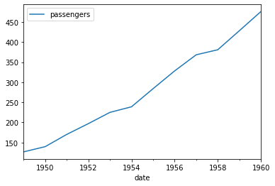

```python
flights.groupby(pd.Grouper(freq='Y')).agg({'passengers':'mean'}).plot()
```

```python
flights.resample('y').mean()
```

| date | year | passengers |
| --- | --- | --- |
| 1949-12-31 | 1949.0 | 126.666667 |
| 1950-12-31 | 1950.0 | 139.666667 |
| 1951-12-31 | 1951.0 | 170.166667 |
| 1952-12-31 | 1952.0 | 197.000000 |
| 1953-12-31 | 1953.0 | 225.000000 |
| 1954-12-31 | 1954.0 | 238.916667 |
| 1955-12-31 | 1955.0 | 284.000000 |
| 1956-12-31 | 1956.0 | 328.250000 |
| 1957-12-31 | 1957.0 | 368.416667 |
| 1958-12-31 | 1958.0 | 381.000000 |
| 1959-12-31 | 1959.0 | 428.333333 |
| 1960-12-31 | 1960.0 | 476.166667 |

```python
flights.index.day_name()
```

```
Index(['Saturday', 'Tuesday', 'Tuesday', 'Friday', 'Sunday', 'Wednesday',
       'Friday', 'Monday', 'Thursday', 'Saturday',
       ...
       'Tuesday', 'Friday', 'Sunday', 'Wednesday', 'Friday', 'Monday',
       'Thursday', 'Saturday', 'Tuesday', 'Thursday'],
      dtype='object', name='date', length=144)
```

```python
flights.resample('y').mean()['passengers'].diff(2)
```

```
date
1949-12-31          NaN
1950-12-31          NaN
1951-12-31    43.500000
1952-12-31    57.333333
1953-12-31    54.833333
1954-12-31    41.916667
1955-12-31    59.000000
1956-12-31    89.333333
1957-12-31    84.416667
1958-12-31    52.750000
1959-12-31    59.916667
1960-12-31    95.166667
Freq: A-DEC, Name: passengers, dtype: float64
```

```python
flights['1950-12-31':].head()
```

| date | year | month | passengers |
| --- | --- | --- | --- |
| 1951-01-01 | 1951 | January | 145 |
| 1951-02-01 | 1951 | February | 150 |
| 1951-03-01 | 1951 | March | 178 |
| 1951-04-01 | 1951 | April | 163 |
| 1951-05-01 | 1951 | May | 172 |

```python
#flights.reset_index(inplace=True)
flights['weekday_name'] = flights['date'].dt.day_name()
```

```python
flights.groupby('weekday_name').size()
```

```
weekday_name
Friday       21
Monday       19
Saturday     20
Sunday       21
Thursday     21
Tuesday      23
Wednesday    19
dtype: int64
```

```python
flights['weekday_name'] = pd.Categorical(flights['weekday_name'], categories=
    ['Monday','Tuesday','Wednesday','Thursday','Friday','Saturday','Sunday'],
    ordered=True)
```

```python
flights.groupby('weekday_name').size()
```

```
weekday_name
Monday       19
Tuesday      23
Wednesday    19
Thursday     21
Friday       21
Saturday     20
Sunday       21
dtype: int64
```

## Exploración de Datos del Titanic

Para esta fase inicial conocer algunas funciones que nos provee pandas para facilitarnos la vida son fundamentales. Dentro de esta fase se desea identificar el dataset que tipo de datos maneja, si tenemos nulos en nuestro conjunto de datos, entre otros.

Estas son algunas funciones que nos sirven para esta fase:

```
df.head()
df.tail()
df.info()
df.shape
df.columns
df.describe()
df.value_counts()
df.unique()
df.nunique()
```

```python
# Visualiza las primeras 2 filas del titanic
titanic.head(2)
```

[output not shown]

```python
# Visualiza las ultimas 2 filas del titanic
titanic.tail(2)
```

[output not shown]

```python
# Conocer cuantas filas y columnas tiene nuestro dataset
titanic.shape
```

[output not shown]

```python
# Tipos de datos que tiene nuestro dataset y que cantidad de nulos tiene
titanic.info()
```

```
<class 'pandas.core.frame.DataFrame'>
Int64Index: 712 entries, 0 to 711
Data columns (total 12 columns):
 #   Column    Non-Null Count  Dtype
---  ------    --------------  -----
 0   survived  712 non-null    int64
 1   pclass    712 non-null    int64
 2   sex       712 non-null    object
 3   age       712 non-null    float64
 4   sibsp     712 non-null    int64
 5   parch     712 non-null    int64
 6   fare      712 non-null    float64
 7   embarked  712 non-null    object
 8   count     712 non-null    int64
 9   family    712 non-null    int64
 10  D_female  712 non-null    uint8
 11  D_male    712 non-null    uint8
dtypes: float64(2), int64(6), object(2), uint8(2)
memory usage: 82.6+ KB
```

```python
# Otra manera de visualizar los nulos por columna
titanic.isnull().sum()
```

```
survived    0
pclass      0
sex         0
age         0
sibsp       0
parch       0
fare        0
embarked    0
count       0
family      0
D_female    0
D_male      0
dtype: int64
```

```python
# Otra manera de conocer los tipos de datos
titanic.dtypes
```

```
survived      int64
pclass        int64
sex          object
age         float64
sibsp         int64
parch         int64
fare        float64
embarked     object
count         int64
family        int64
D_female      uint8
D_male        uint8
dtype: object
```

```python
# Resumen de las columnas numericas
titanic.describe()
```

|  | survived | pclass | age | sibsp | parch | fare | count | family | D_female | D_male |
| --- | --- | --- | --- | --- | --- | --- | --- | --- | --- | --- |
| count | 712.000000 | 712.000000 | 712.000000 | 712.000000 | 712.000000 | 712.000000 | 712.000000 | 712.000000 | 712.000000 | 712.000000 |
| mean | 0.404494 | 2.240169 | 29.642093 | 0.514045 | 0.432584 | 34.567251 | 1.772472 | 0.394663 | 0.363764 | 0.636236 |
| std | 0.491139 | 0.836854 | 14.492933 | 0.930692 | 0.854181 | 52.938648 | 1.272417 | 0.489122 | 0.481420 | 0.481420 |
| min | 0.000000 | 1.000000 | 0.420000 | 0.000000 | 0.000000 | 0.000000 | 1.000000 | 0.000000 | 0.000000 | 0.000000 |
| 25% | 0.000000 | 1.000000 | 20.000000 | 0.000000 | 0.000000 | 8.050000 | 1.000000 | 0.000000 | 0.000000 | 0.000000 |
| 50% | 0.000000 | 2.000000 | 28.000000 | 0.000000 | 0.000000 | 15.645850 | 1.000000 | 0.000000 | 0.000000 | 1.000000 |
| 75% | 1.000000 | 3.000000 | 38.000000 | 1.000000 | 1.000000 | 33.000000 | 2.000000 | 1.000000 | 1.000000 | 1.000000 |
| max | 1.000000 | 3.000000 | 80.000000 | 5.000000 | 6.000000 | 512.329200 | 7.000000 | 1.000000 | 1.000000 | 1.000000 |

```python
# Resumen de las columnas categoricas
titanic.describe(include = ['O'])
```

|  | sex | embarked |
| --- | --- | --- |
| count | 712 | 712 |
| unique | 2 | 3 |
| top | male | S |
| freq | 453 | 554 |

```python
# Valores unicos por columna sin tener en cuenta nulos
titanic.nunique()
```

```
survived      2
pclass        3
sex           2
age          88
sibsp         6
parch         7
fare        219
embarked      3
count         7
family        2
D_female      2
D_male        2
dtype: int64
```

```python
# Valores unicos por columna teniendo en cuenta nulos
titanic.nunique(dropna=False)
```

```
survived      2
pclass        3
sex           2
age          88
sibsp         6
parch         7
fare        219
embarked      3
count         7
family        2
D_female      2
D_male        2
dtype: int64
```

```python
# Conteo de valores por columna de no nulos
titanic.count()
```

```
survived    712
pclass      712
sex         712
age         712
sibsp       712
parch       712
fare        712
embarked    712
count       712
family      712
D_female    712
D_male      712
dtype: int64
```

```python
# Valor mas frecuente en la serie
titanic['embarked'].mode()
```

```
0    S
dtype: object
```

```python
# Valores unicos de la columna 'Embarked'
titanic['embarked'].unique()
```

```
array(['S', 'C', 'Q'], dtype=object)
```

```python
# Cuantos registros tenemos por categoria de la columna 'Embarked' sin nulos
titanic['embarked'].value_counts()
```

```
S    554
C    130
Q     28
Name: embarked, dtype: int64
```

```python
# Cuantos registros tenemos por categoria de la columna 'Embarked' con nulos
titanic['embarked'].value_counts(dropna=False)
```

```
S    554
C    130
Q     28
Name: embarked, dtype: int64
```

```python
# Cuales son los nombres de las columnas del dataset
titanic.columns
```

```
Index(['survived', 'pclass', 'sex', 'age', 'sibsp', 'parch', 'fare',
       'embarked', 'count', 'family', 'D_female', 'D_male'],
      dtype='object')
```

```python
titanic.columns = ['Passenger_Id', 'Survived', 'Pclass', 'Name', 'Sex', 'Age', 'SibSp',
       'Parch', 'Ticket', 'Fare', 'Cabin', 'Embarked']
titanic = titanic.rename(columns={'Passenger_Id':'PassengerId'})
titanic.head()
```

|  | PassengerId | Survived | Pclass | Name | Sex | Age | SibSp | Parch | Ticket | Fare | Cabin | Embarked |
| --- | --- | --- | --- | --- | --- | --- | --- | --- | --- | --- | --- | --- |
| 0 | 0 | 3 | male | 22.0 | 1 | 0 | 7.2500 | S | 1 | 0 | 0 | 1 |
| 1 | 1 | 1 | female | 38.0 | 1 | 0 | 71.2833 | C | 1 | 0 | 1 | 0 |
| 2 | 1 | 3 | female | 26.0 | 0 | 0 | 7.9250 | S | 1 | 0 | 1 | 0 |
| 3 | 1 | 1 | female | 35.0 | 1 | 0 | 53.1000 | S | 2 | 1 | 1 | 0 |
| 4 | 0 | 3 | male | 35.0 | 0 | 0 | 8.0500 | S | 1 | 0 | 0 | 1 |

```python
?titanic.rename
```

```python
titanic[(titanic['Embarked']=='S') & (titanic['Sex']=='female')][['Name','Age']].head()
```

|  | Name | Age |
| --- | --- | --- |